# Webtoon Genre Popularity and Ratings: Demo

## An investigation into the different comic genres and how their popularity affects how their user rating.

[figure not shown]

### Overview

Webtoons are another name for comics that are published and regularly updated online. The platform Webtoon is a website dedicated to the publication of serialized comics (made by professional companies), and also allows for users to upload their own self-written comics. Within the platform, there are comics of all different genres published, each with varying popularities.

[figure not shown]

The more popular genres tend to be displayed at the top, while less popular genres are lumped under the "other" category. This is because the most popular genres tend to have the most stories- but that doesn't necessarily mean they're good. From personal experience, I can say that while more popular stories have more views, that doesn't necessarily mean they're more well received. I have read my fair share of comics that are, by relative standards, extremely popular, but also absolutely terrible. So, when I was browsing through publicaly available datasets for my project and found one that contained information about all the published comics on Webtoon, I decided to investigate whether or not more popular genres actually deserved the popularity.

Thus, my research question was: **If a genre is more popular, will it be rated differently? Will stories in this genre have a higher, lower, or similar average rating?**

### Program Design

There is a lot of information that is publically accessible.

[figure not shown]

Each comic has likes, and you can like every chapter once. There are also subscriber counts and an user average rating, which are highlighted above. I wanted to compare a genre's average popularity with the average rating of all the stories in the genre.

But how do you define "popularity?". The metric I originally wanted to go with was the average number of likes for each chapter of a comic. However, the number of chapters isn't available to easily compile, and I would have to manually count, which isn't feasible. So I decided to define it in a different way:

**Popularity is the average number of subscribers for stories in a given genre.**

This allows me to see the average number of readers who are continuously following or keeping up with comics in this genre. Unlike likes, this is a more accurate way to visualize the amount of people who are actively following stories.

I decided to make a scatterplot to visualize the relationship between popularity and average rating because they are 2 independently measured variables. In total, there were around 550 comics spread across 16 unique genres.

### Final Idea - Concept Drawing of Expected Output

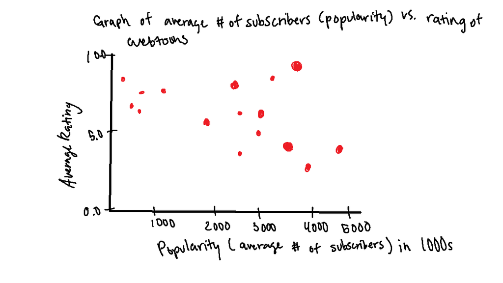

### Sorting the Data

To create the graph, I first had to **sort and analyze the data**. This involved extracting relevant information from the CSV into a data definition.

[figure not shown]

In creating the read function, I needed the genre to sort the comics into the related categories, the rating, and the subscriber count. As you notice, the number of subscribers is in short form; there were "M"s behind numbers if the subscribers was in the millions and "K"s behind numbers to show the count was in the thousands (not shown above). So, in order to parse the information and store it as a float, I had to go through and remove all the Ms or Ks and then convert the float into a specific magnitude- either thousands or millions.

I had anticipated this would be the most difficult part, but it was actually quite simple.

```
@typecheck
def parse_subs(subs: str) -> float:
    """
    Given a string of numbers representing number of subscribers, returns number of subscribers as float in thousands.
    If string ends with "M", meaning the value is currently in millions, removes "M", parses into float, and multiplies
    value by 1000 to convert into thousands.
    If string ends with "K", meaning value is currently in thousands, removes "K" and parses into float.
    """
    # return 0.0 # stub
    # template based on atomic non-distinct
    if subs[-1] == "M":
        return parse_float(subs[:-1]) * 1000
    elif subs[-1] == "K":
        return parse_float(subs[:-1])
```

Once I stored all my data into a new compound, I could start to analyze it.

### Analyzing the Data

Steps:

1. Sort the comics into their respective genres.
2. Count the total number of stories in each genre.
3. Calculate the popularity (average number of subscribers) of the genre.
4. Calculate the average rating for the genre.
5. Graph popularity vs. rating, with marker size = total number of stories.

This sounds easy on paper, but I had to use a lot of helpers.

Steps 1 and 2 were very simple. We've done very similar questions in class. If the genre of the comic matches the given genre, append it to the list (for filtering, shown below) or increase the count by 1 (counting total in genre) using for loops.

```
@typecheck
def filter_by_genre(lowd: List[WebtoonData], g: Genre) -> List[WebtoonData]:
    """
    given a list of webtoon data and a Genre, filters and returns a list of webtoon data of the same genre.
    """
    # return [] # stub
    # template based on List[WebtoonData] with additional parameter and reference rule

    # filtered is all the webtoon data seen so far with the correct genre

    filtered = [] # Type: List[WebtoonData]

    for wd in lowd:
        if same_genre(wd, g) == True:
            filtered = filtered + [wd]

    return filtered
```

For steps 3 and 4, I needed to use the composition skills we learned about in the one task per function module because I needed to incorporate a lot of different individual functions to create one unified output. I've included the example for average subscribers below.

```
@typecheck
def average_subs(lowd: List[WebtoonData], g: Genre) -> float:
    """
    given a list of WebtoonData, returns the average number of subscribers for webtoons in a given genre
    ASSUME: the list of webtoon data has at least 1 item that has the same genre as the given genre
    """
    # return 0.0 # stub
    # template based on composition and reference rule
    # Plan:
    # 1. filter list by genre
    # 2. count number of items in filtered list
    # 3. find the total number of subscribers to webtoons in the genre
    # 4. calculate the average number of subscribers by dividing the total number of subscribers by the number of items

    filtered_list = filter_by_genre(lowd, g)
    total_webtoons = count_webtoons(filtered_list)
    total_subs = sum_subs(filtered_list)
    average_subs = total_subs/total_webtoons
    return average_subs
```

I also had to make the assumption that the list had at least 1 item that matched the input genre because you divide by the total number of webtoons at some point, and you can't divide a number by 0. This was done for both subscribers and rating.

Now: the most challenging part. **We need to graph the information for all genres. How can we ensure that all the data we have is paired correctly, and in the same order?**

The solution: Graph the information using lists, which have a set order. If we make a new data definition for List of Genres, we can use that to create a new list that has information in the same order as the other lists used previously.

```
LOG16 = [Genre.Romance, Genre.Supernatural, Genre.Fantasy, Genre.Action, Genre.Thriller, Genre.Mystery,
         Genre.Comedy, Genre.Heartwarming, Genre.Slice_of_life, Genre.Sci_fi, Genre.Historical,
         Genre.Sports, Genre.Superhero, Genre.Informative, Genre.Horror, Genre.Drama]


@typecheck
def av_subs_all_genres(lowd: List[WebtoonData], log: List[Genre]) -> List[float]:
    """
    given a list of webtoon data and a list of genres, returns a list of the average number of subscribers in thousands
    for webtoons in each genre in the list
    ASSUME: log contains all unique genres present in lowd
    ASSUME: log does NOT contain genres that are not in lowd; log only has genres found in lowd
    """
    # return [] # stub
    # template based on List[Genre] with additional parameter and reference rule

    # loa represents the list of average ratings so far
    loa = [] # type: List[float]
    for g in log:
        loa = loa + [average_subs(lowd, g)]

    return loa
```

By doing this, you can get lists for subscribers, number of comics, and ratings in the exact order you want, and in the same order every time. So when your graphing, the data is paired up accurately.

CAVEATS: run into errors if you have genres that are in List[Genre] but not in List[WebtoonData] or vice versa.

The other error that made the project challenging were the errors in the dataset. The dataset drew from publically availably information and the person who compiled it made some errors. All my tests with smaller datasets ran perfectly fine, but the whole set couldn't work and I had no idea why. I spent the next hour fixing errors in the dataset. This included:

1. Errors in the subscriber count. One item had "k" instead of "K", and one other one had a typo that said "23K0".
2. Spaces in the summary. If the summary included paragraphs, Jupyter read it as an entirely separate line, which ran into issues because it could not parse blank space. So I had to go and manually remove all the spaces in the summaries.

### The Graph

After sorting and analyzing the data, the graph was pretty straightforward.

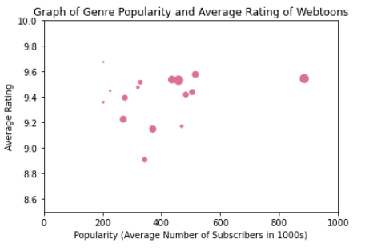

Based on the results, we can see:

1. Most genres hover around 200-600 thousands subscribers per story. The one outlier is Romance.
2. All genres had at least an average rating of 8.8/10. The most highly rated genre on average was Heartwarming.
3. The genre with the most comics was Fantasy, with Romance close behind. The genre with the least stories was Heartwarming.

There doesn't seem to be any trends. More popular genres don't seem to be rated any differently, and the number of stories in the genre doesn't seem to have an affect on the average rating. With one exception, it does appear that smaller genres are less popular.

## Final Thoughts

This project was fun and really helped answer a question that was itching at the back of my mind. If I were someone who was working on the Webtoon platform, these statistics would be really helpful to see what genres are more popular than others, and if there are certain genres that are lacking in quality compared to others. It would also help inform advertising and investment into resources for certain genres that might be more popular but have low amounts of comics.

In the future:

I could design a program that would look at the "likes" system to see if there is a relationship between number of subscribers and likes in order to explore the idea of reader retention; are the people liking your story actually following it?

I could also look at likes and average rating, or if there are certain days of the week that are correlated with higher popularity so I can tell when it's the most advantageous to release my story if I was a writer.